# Name: Sunday Okechukwu & Dhruv Jain

## Contibution:

Sunday Okechukwu: Data gatering, data cleaning , data pre-processing, Evaluation, Results.  
Dhruv Jain: Feature engineering, Model development, Summary, Future work.

# Machine Translation

##### What is `Machine Translation??`

Loosely speaking `Machine Translation` refers to the automated process of translating text or speech from one language called (source language) to another language called (target language). For eg. frn-eng or spn-eng.

Technically, it involves training machine learning models on large datasets of parallel text, where the same text is available in two or more languages

##### Why `Machine Translation`?

##### `There are several use cases of machine translation, such as those given below:`

- Internal communication

For a company operating in different countries across the world, communication can be difficult to manage. Machine translation helps to lower or eliminate the language barrier in communication.

- Data analysis

Companies translate the large amount of content posted on social media and websites every day, and translate it for analytics. For example, they can automatically analyze customer opinions written in various languages.

- Online customer service

Accurately translate requests from customers all over the world.

Increase the scale of live chat and automate customer service emails.

Improve the customer experience without hiring more employees.

- Legal research

The legal department uses machine translation for preparing legal documents in different countries.

## Common types of MT

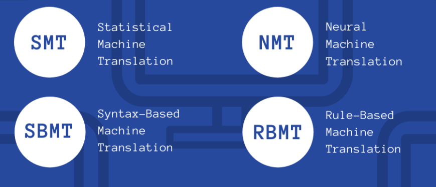

## Goal:

The goal of this project is to build a deep neural network that functions as part of an end-to-end Neural Machine Translation. The pipeline when completed will accepts French senetences as input and return the English Translation

## Brief Description of the dataset

We will be working on a language dataset available [here](http://www.manythings.org/anki/).

This site contains a dataset of numerous languages and its translation to English. You can download any language dataset as per your preference and comfort. Here, we will be downloading French-English dataset which comprises of 217975 sentences.

## Main stages of the Project

- Preprocessing
- Feature Extraction
- Modelling
- Evaluations
- Summary and direction for future work

## Preprocessing

- Normalizing case to lowercase and unicode normalization.
- Removing punctuation from each word.
- Removing words that contain non-alphabetic characters.

## Advanced preprocessing

For this project, we won't use text data as input to the model. Instead, we will convert the text into sequences of integers using the following preprocess methods:

1. Tokenize the words into ids
2. Add padding to make all the sequences the same length.

## Example results of the tokenization

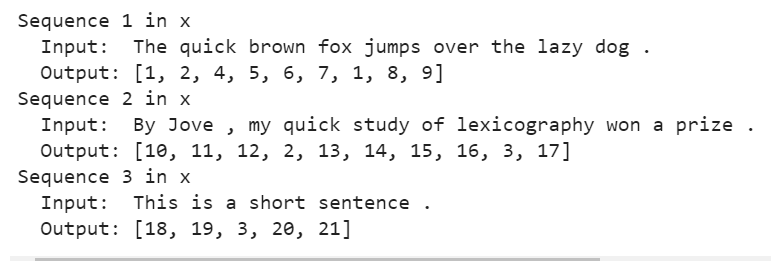

## Example results of the padding

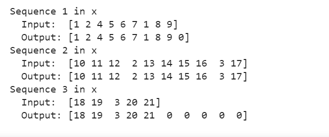

## Feature extraction

Here, instead of using pre-trained word embeddings such as GloVe. We shall train our own embeddings using Keras embedding layer.

`Word embeddings can be thought of as an alternate to one-hot encoding along with dimensionality reduction.`

Embedding layer enables us to convert each word into a fixed length vector of defined size.

There are three parameters to the embedding layer

- input_dim : Size of the French vocabulary
- output_dim : shape of the embedding vector
- input_length : Maximum length of the input sequence

## Model Development

### Model Architecture

We’ll start off by defining our Seq2Seq model architecture:

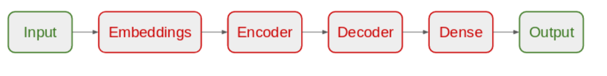

- For the encoder, we will use an embedding layer and stack of LSTM layers
- For the decoder, we will use another stack of LSTM layers followed by a dense layer

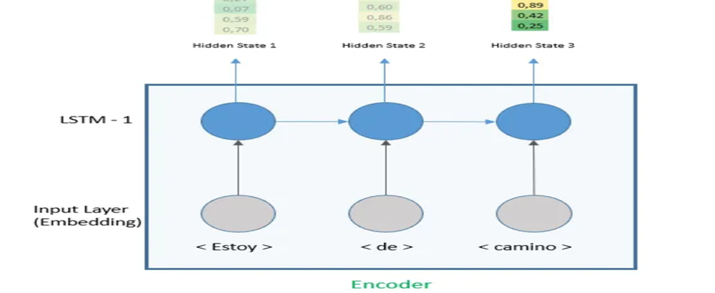

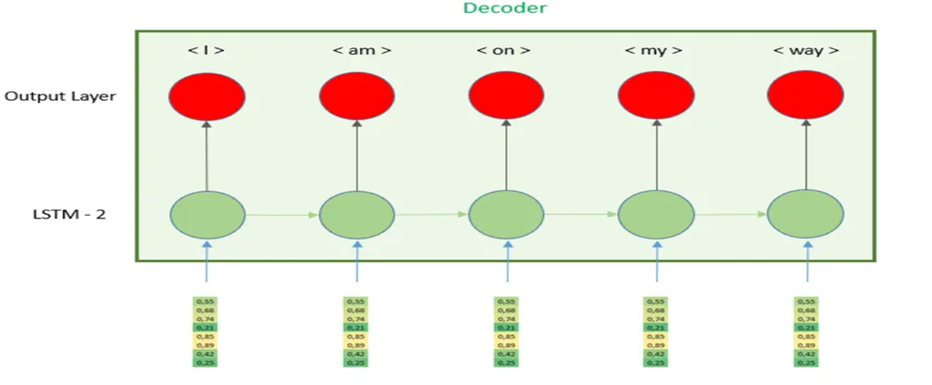

- Encoder: The encoder processes each token in the input-sequence. It tries to cram all the information about the input-sequence into a vector of fixed length i.e. the ‘context vector’.
- Context vector: The vector is built in such a way that it's expected to encapsulate the whole meaning of the input-sequence and help the decoder make accurate predictions.
- Decoder: The decoder reads the context vector and tries to predict the target-sequence token by token. It is also built with LSTM layers and a dense layer to predict the English word.

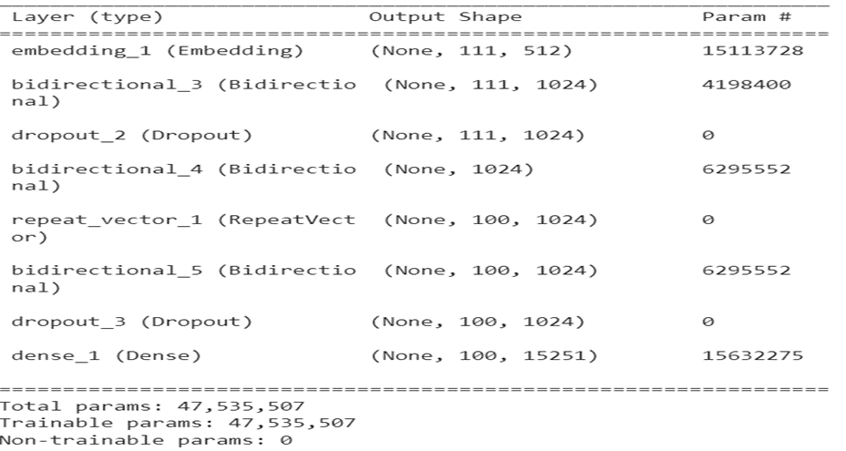

One of the major advantages of this model is that the length of the input and output sequences may differ. This opens the door for very interesting applications such as machine translation, video captioning or question and answer.

The major limit of this simple encoder decoder model is that all the information needs to be summarized in one dimensional vector, for long input sequences that can be extremely difficult to achieve. Having said that, understanding encoder decoder models is key for the latest advances in NLP because it is the seed for attention models and transformers.

## Evaluations and Results

### Results on the train set

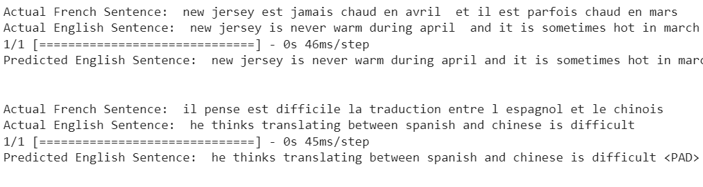

### Results on the test set

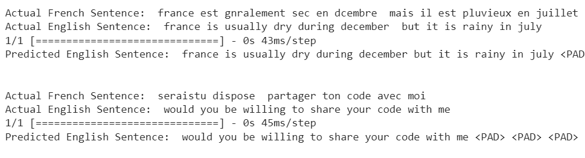

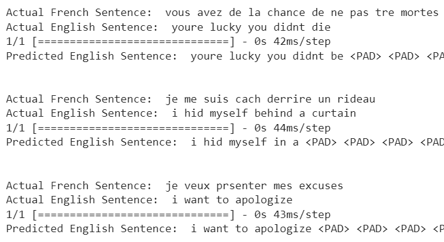

## The Bleu Score

##### What is the Bleu Metric?

It is used to measure the quality of text translated from a model The idea behind Bleu is to assign a single numerical score to a translation that tells us how good it is when compared to one or more human reference translations The approach that Bleu takes is to comapare the ngrams of the generated translations to the ngrams of the refrences

## Bleu is based on ngram precision to measure translation quality

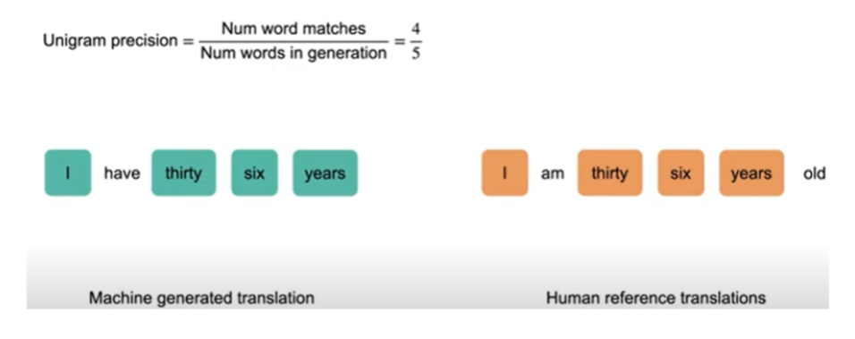

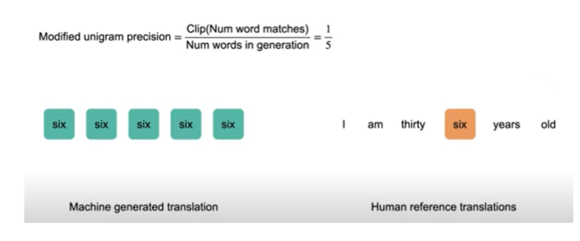

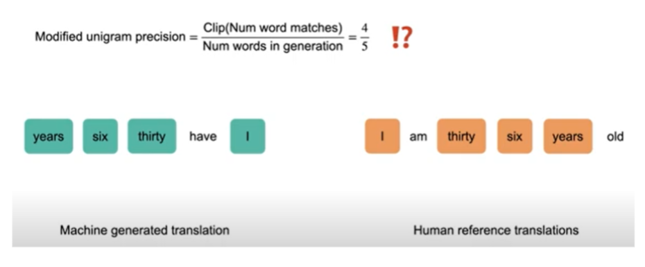

To deal with word order, Bleu actually calculates the precision for several different ngrams and averages the result

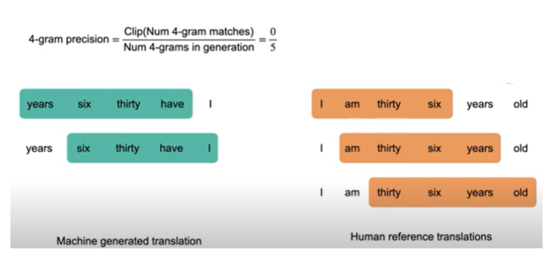

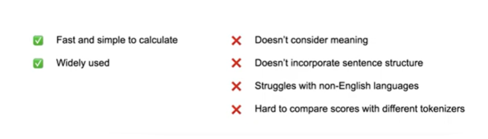

## Bleu Score with the test set

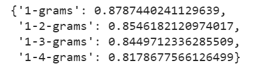

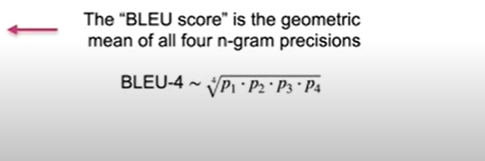

**BLEU-4 = 0.8487697339546985**

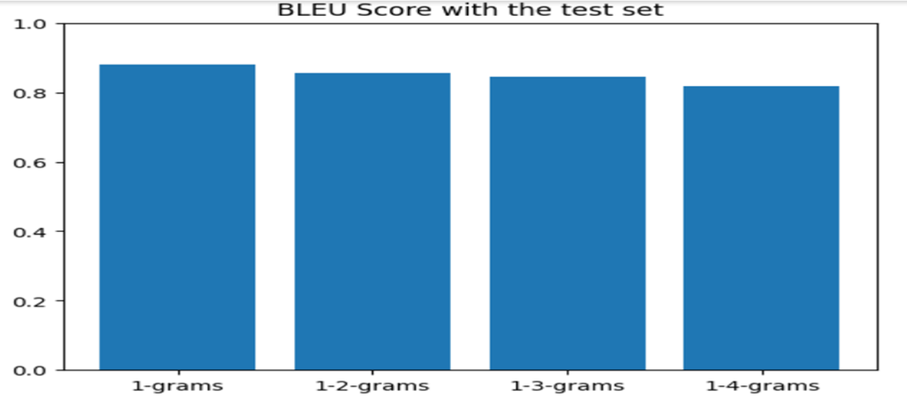